# FP

```r
library(tidyverse)
library(rstan)
library(rstanarm)
library(bayesplot)
```

```r
options(mc.cores = parallel::detectCores())
rstan_options(auto_write = TRUE)
rstan_options(threads_per_chain = 2)
```

```r
base_url <- "https://exoplanetarchive.ipac.caltech.edu/TAP/sync"
query_string <- "select+pl_name,disc_year,pl_rade,pl_orbper,st_met,st_teff,discoverymethod,st_mass,sy_pnum+from+ps+where+default_flag=1&format=csv"
full_url <- paste0(base_url, "?query=", query_string)

raw_planets <- read_csv(full_url)
clean_data <- raw_planets %>%
  mutate(
    log_radius = log(pl_rade),
    log_period = log(pl_orbper),
    log_st_mass = log(st_mass),
    st_teff_k = st_teff / 1000,
    method_group = fct_lump(discoverymethod, n = 3)
  ) %>%
  filter(
    !is.na(disc_year),
    !is.na(log_radius),
    !is.na(log_period),
    !is.na(st_met),
    !is.na(st_teff_k),
    !is.na(discoverymethod),
    !is.na(log_st_mass)
  )

print(nrow(clean_data))
```

```
## [1] 3403
```

```r
head(clean_data)
```

```
## # A tibble: 6 × 14
##   pl_name   disc_year pl_rade pl_orbper st_met st_teff discoverymethod st_mass
##   <chr>         <dbl>   <dbl>     <dbl>  <dbl>   <dbl> <chr>             <dbl>
## 1 WASP-96 b      2014   13.4       3.43   0.14    5540 Transit           1.06
## 2 HAT-P-1 b      2006   14.8       4.47   0.13    5980 Transit           1.15
## 3 WASP-17 b      2009   21.0       3.74  -0.25    6550 Transit           2.28
## 4 WASP-62 b      2012   14.8       4.41   0.04    6230 Transit           1.11
## 5 KELT-7 b       2015   17.9       2.73   0       6768 Transit           1.76
## 6 GJ 3470 b      2012    4.57      3.34   0.2     3600 Radial Velocity   0.539
## # ℹ 6 more variables: sy_pnum <dbl>, log_radius <dbl>, log_period <dbl>,
## #   log_st_mass <dbl>, st_teff_k <dbl>, method_group <fct>
```

## Stan model, MCMC

We model:
$$y_i \sim
Poisson(\lambda)$$
$$\lambda \sim
Gamma(2,0.1)$$

```r
yearly_counts <- clean_data %>%
  count(disc_year) %>%
  rename(n_planets = n)

head(yearly_counts)
```

```
## # A tibble: 6 × 2
##   disc_year n_planets
##       <dbl>     <int>
## 1      1999         1
## 2      2001         1
## 3      2004         3
## 4      2005         3
## 5      2006         3
## 6      2007        11
```

```r
poisson_stan_code <- "
data {
  int<lower=0> N;
  int<lower=0> y[N];
}
parameters {
  real<lower=0> lambda;
}
model {
  lambda ~ gamma(2, 0.1);
  y ~ poisson(lambda);
}
"

stan_data <- list(
  N = nrow(yearly_counts),
  y = yearly_counts$n_planets
)

poisson_fit <- stan(
  model_code = poisson_stan_code,
  data = stan_data,
  iter = 2000,
  chains = 4
)
```

## Prior Diagnostics, Trace Plot

```r
print(poisson_fit, pars = "lambda")
```

```
## Inference for Stan model: anon_model.
## 4 chains, each with iter=2000; warmup=1000; thin=1;
## post-warmup draws per chain=1000, total post-warmup draws=4000.
##
##          mean se_mean   sd   2.5%    25%    50%    75% 97.5% n_eff Rhat
## lambda 141.36    0.06 2.37 136.88 139.72 141.34 142.94 146.1  1575    1
##
## Samples were drawn using NUTS(diag_e) at Mon Dec  8 01:36:19 2025.
## For each parameter, n_eff is a crude measure of effective sample size,
## and Rhat is the potential scale reduction factor on split chains (at
## convergence, Rhat=1).
```

```r
color_scheme_set("brightblue")

mcmc_trace(
  as.array(poisson_fit),
  pars = "lambda"
)
```

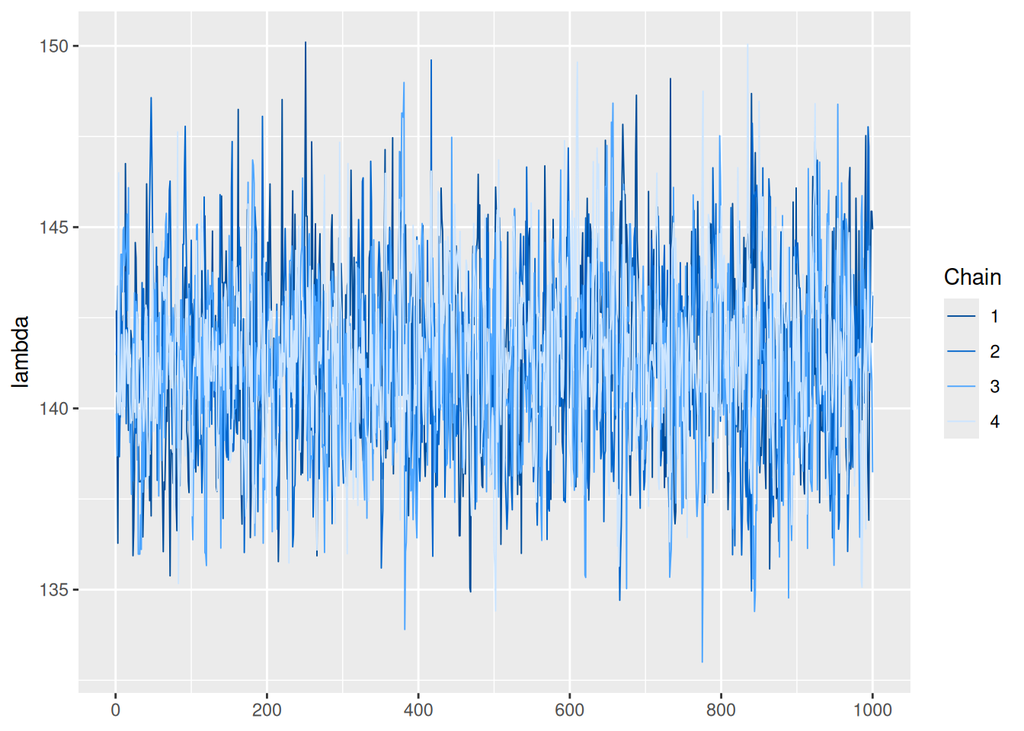

## Density Plot

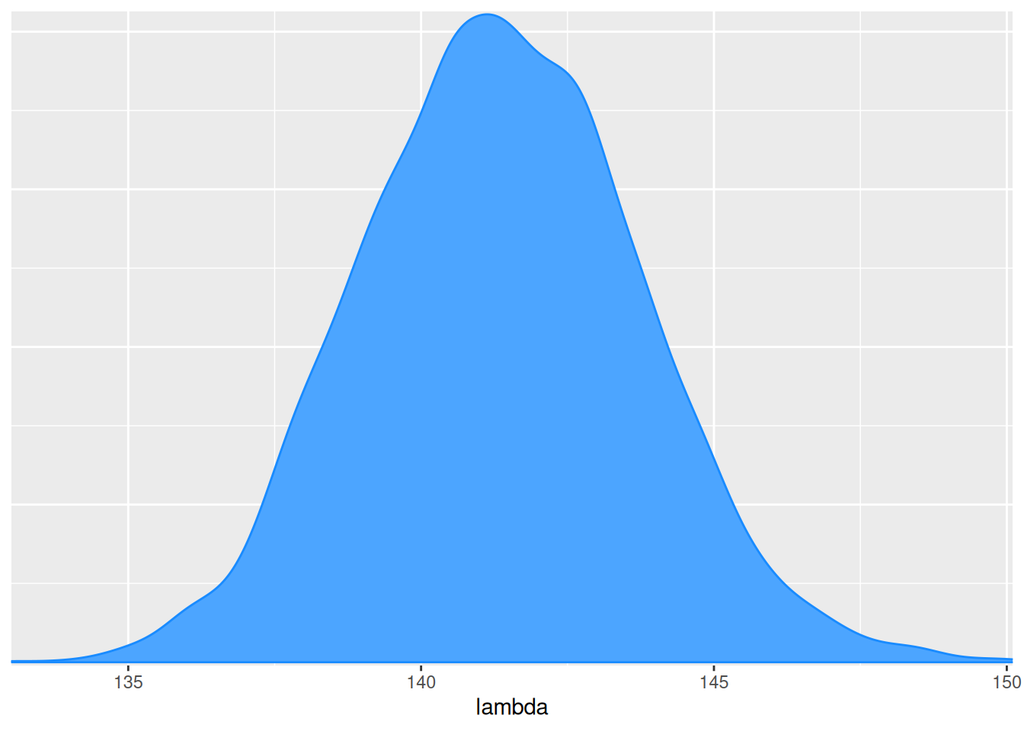

```r
mcmc_dens(as.array(poisson_fit), pars = "lambda")
```

## Autocorrelation Plot

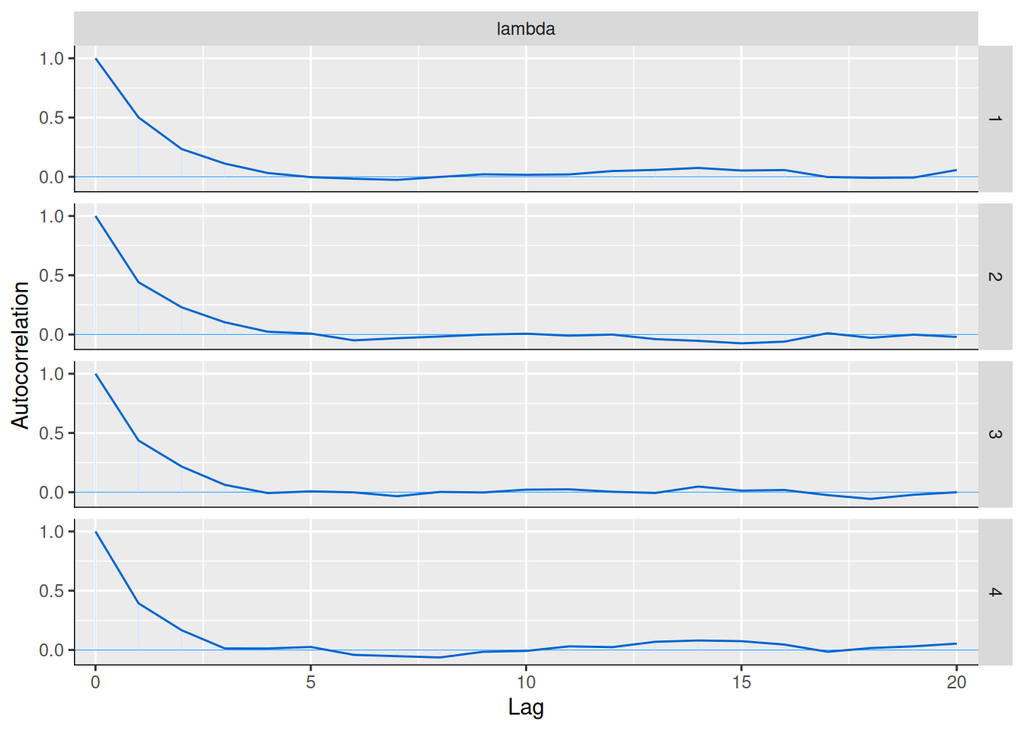

```r
mcmc_acf(as.array(poisson_fit), pars = "lambda")
```

## R-Hat, Effective Sample Size

```r
summary(poisson_fit)$summary[, c("Rhat", "n_eff")]
```

```
##            Rhat    n_eff
## lambda 1.002528 1575.236
## lp__   1.001712 1704.039
```

## Closed Form Posterior

We model:

$$\lambda | y \sim Gamma(a + \Sigma y,
\beta + N)$$

```r
alpha_prior <- 2
beta_prior <- 0.1

sum_y <- sum(yearly_counts$n_planets)
N <- nrow(yearly_counts)
alpha_post <- alpha_prior + sum_y
beta_post <- beta_prior + N

#posterior mean
alpha_post / beta_post
```

```
## [1] 141.2863
```

## Comparison with MCMC mean

```r
posterior_samples <- extract(poisson_fit)$lambda
mean(posterior_samples)
```

```
## [1] 141.3595
```

Here, we modeled the yearly number of exoplanet discoveries using a Poisson likelihood with $Gamma (2,0.1)$ prior on the rate parameter $\gamma$. We estimated the posterior distribution using Hamiltonian Monte Carlo via Stan. Trace plots, density plots, and autocorrelation diagnostics indicate good chain mixing, given R-hat values hover around 1.00 and effective sample sizes appear high. We also derived the closed-form Gamma posterior due to conjugacy and found strong agreement between the theoretical posterior mean and the MCMC based posterior mean, confirming correct model implementation and convergence

## Stan model, MCMC

We model:
$$y_i \sim \mathcal{N}(\mu,
\sigma)$$
$$\mu \sim \mathcal{N}(5,
5)$$
$$\sigma \sim \text{Cauchy}(0,
5)$$

```r
y_val <- clean_data$log_period
N_val <- length(y_val)

mu_prior_mean <- 5.0
mu_prior_sd   <- 5.0

stan_data_continuous <- list(
  N    = N_val,
  y    = y_val,
  mu0  = mu_prior_mean,
  tau0 = mu_prior_sd
)

continuous_stan_code <- "
data {
  int<lower=0> N;
  vector[N] y;
  real mu0;
  real tau0;
}
parameters {
  real mu;
  real<lower=0> sigma;
}
model {
  // Priors
  mu ~ normal(mu0, tau0);
  sigma ~ cauchy(0, 5); // Half-cauchy for scale

  // Likelihood
  y ~ normal(mu, sigma);
}
"

fit_continuous <- stan(
  model_code = continuous_stan_code,
  data = stan_data_continuous,
  iter = 10000,
  chains = 4
)
```

## Prior Diagnostics, Trace Plot

```r
print(fit_continuous, pars = c("mu", "sigma"))
```

```
## Inference for Stan model: anon_model.
## 4 chains, each with iter=10000; warmup=5000; thin=1;
## post-warmup draws per chain=5000, total post-warmup draws=20000.
##
##       mean se_mean   sd 2.5%  25%  50%  75% 97.5% n_eff Rhat
## mu    2.17       0 0.02 2.13 2.16 2.17 2.19  2.21 20041    1
## sigma 1.29       0 0.02 1.26 1.28 1.29 1.30  1.32 20832    1
##
## Samples were drawn using NUTS(diag_e) at Mon Dec  8 01:37:27 2025.
## For each parameter, n_eff is a crude measure of effective sample size,
## and Rhat is the potential scale reduction factor on split chains (at
## convergence, Rhat=1).
```

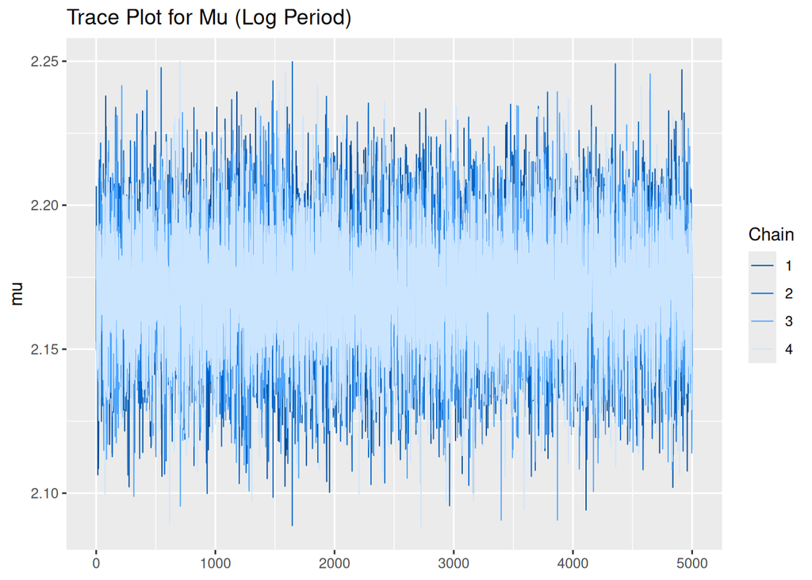

```r
color_scheme_set("brightblue")

mcmc_trace(
  as.array(fit_continuous),
  pars = "mu"
) + ggtitle("Trace Plot for Mu (Log Period)")
```

## Density Plot

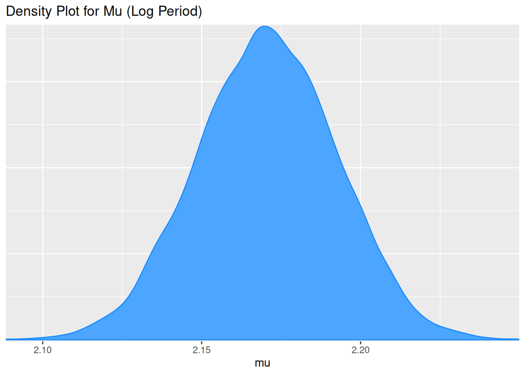

```r
mcmc_dens(as.array(fit_continuous), pars = "mu") +
  ggtitle("Density Plot for Mu (Log Period)")
```

## Autocorrelation Plot

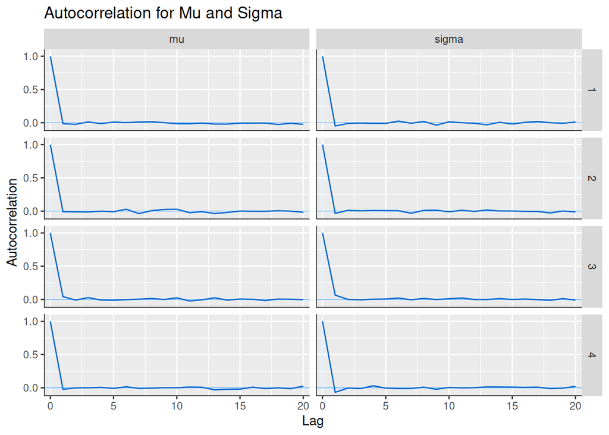

```r
mcmc_acf(as.array(fit_continuous), pars = c("mu", "sigma")) +
  ggtitle("Autocorrelation for Mu and Sigma")
```

## R-Hat, Effective Sample Size

```r
summary(fit_continuous)$summary[, c("Rhat", "n_eff")]
```

```
##           Rhat     n_eff
## mu    1.000078 20041.124
## sigma 1.000263 20831.928
## lp__  1.000332  9169.615
```

## Closed Form Posterior (Approximate)

Assuming $\sigma$ is fixed at the sample standard deviation, we compare against the conjugate Normal-Normal update:

$$\frac{1}{\sigma^2_{post}} =
\frac{1}{\tau_0^2} + \frac{N}{\sigma^2_{data}}$$
$$\mu_{post} = \sigma^2_{post} \left(
\frac{\mu_0}{\tau_0^2} + \frac{N\bar{y}}{\sigma^2_{data}}
\right)$$

```r
sigma_data <- sd(y_val)
y_bar      <- mean(y_val)

prior_prec <- 1 / (mu_prior_sd^2)
data_prec  <- N_val / (sigma_data^2)

post_var_theo <- 1 / (prior_prec + data_prec)

# Posterior mean
post_mean_theo <- post_var_theo * ( (mu_prior_mean * prior_prec) + (y_bar * data_prec) )
post_mean_theo
```

```
## [1] 2.170862
```

## Comparison with MCMC mean

```r
mcmc_mean <- summary(fit_continuous)$summary["mu", "mean"]
mcmc_mean
```

```
## [1] 2.170532
```

Here, we modeled the log period of exoplanets using a Normal likelihood with a Normal prior on the mean $\mu$ and a Half-Cauchy prior on $\sigma$. We estimated the posterior distribution using Hamiltonian Monte Carlo via Stan. Trace plots, density plots, and autocorrelation diagnostics indicate good chain mixing, given R-hat values hover around 1.00 and effective sample sizes appear high. We also derived the closed-form Normal posterior (conditional on $\sigma$ being known) and found strong agreement between the theoretical posterior mean and the MCMC based posterior mean, confirming correct model implementation and convergence.

# Bayesian Regression Model

We fit a multiple linear regression model to predict the log orbital period (`log_period`) based on stellar mass, effective temperature, metallicity, and the number of planets in the system.

The model specification is:

$$y_i \sim \mathcal{N}(\mu_i, \sigma)$$

$$\mu_i = \alpha + \beta_1 (\text{log\_st\_mass}) + \beta_2
(\text{st\_teff\_k}) + \beta_3 (\text{st\_met}) + \beta_4
(\text{sy\_pnum})$$

**Priors:**

- **Coefficients (**$\beta$**):** We use weakly informative Normal priors $\mathcal{N}(0, 2.5)$ (scaled). This assumes that without seeing the data, we expect the effect sizes to be relatively small but allows for larger effects if the data supports them.
- **Intercept (**$\alpha$**):** We use a Normal prior $\mathcal{N}(0, 10)$, centering the baseline expectation near 0 but with wide variance.
- **Auxiliary (**$\sigma$**):** We use an Exponential prior $\text{Exp}(1)$ for the error standard deviation, constraining it to be positive and penalizing extremely large residual variance.

```r
# Fit the model using rstanarm
fit_stanarm <- stan_glm(
  log_period ~ log_st_mass + st_teff_k + st_met + sy_pnum,
  data = clean_data,
  family = gaussian(),

  prior = normal(location = 0, scale = 2.5, autoscale = TRUE),
  prior_intercept = normal(location = 0, scale = 10, autoscale = TRUE),
  prior_aux = exponential(rate = 1, autoscale = TRUE),

  chains = 4,
  iter = 2000,
  seed = 123
)
```

## Diagnostics

We apply the same MCMC diagnostics used in the previous sections to ensure convergence.

### Trace Plots

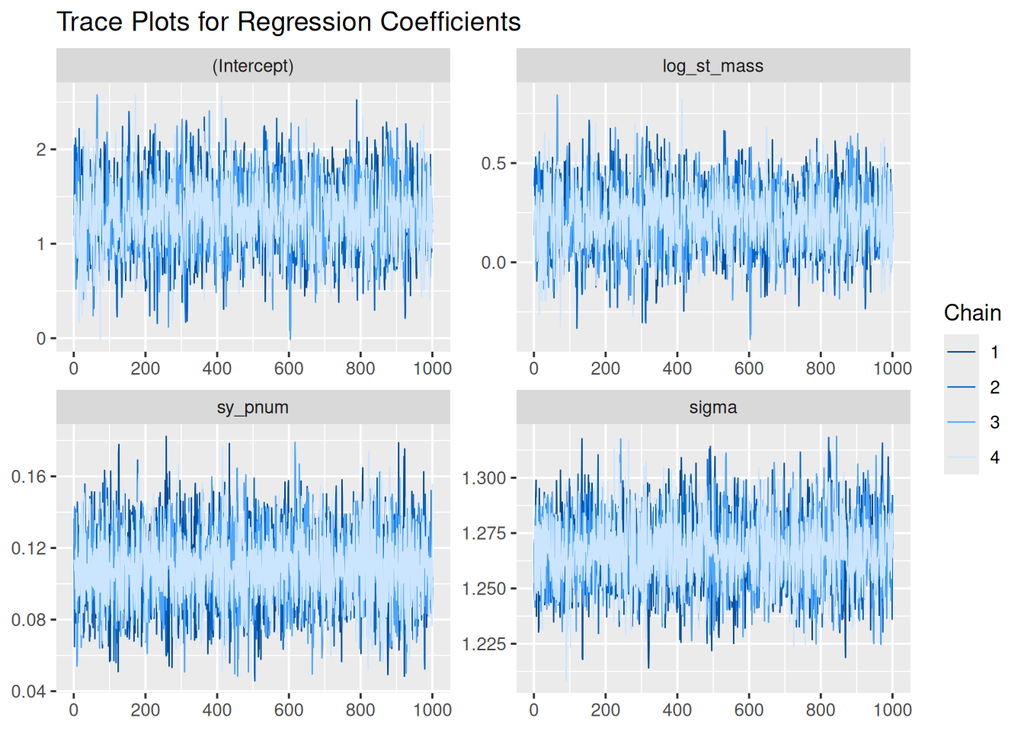

```r
# Convert stanreg object to array for bayesplot functions
posterior_arr <- as.array(fit_stanarm)

# Plotting trace for a subset of interesting parameters
mcmc_trace(posterior_arr, pars = c("(Intercept)", "log_st_mass", "sy_pnum", "sigma")) +
  ggtitle("Trace Plots for Regression Coefficients")
```

### Density Plots

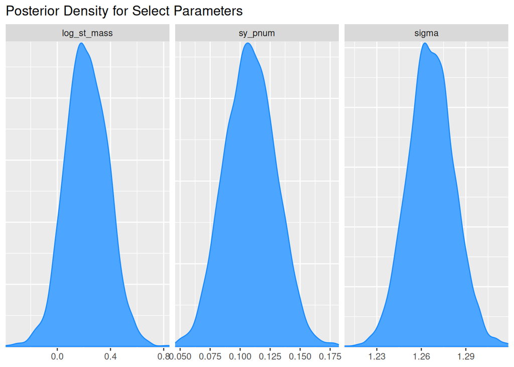

```r
mcmc_dens(posterior_arr, pars = c("log_st_mass", "sy_pnum", "sigma")) +
  ggtitle("Posterior Density for Select Parameters")
```

### Autocorrelation

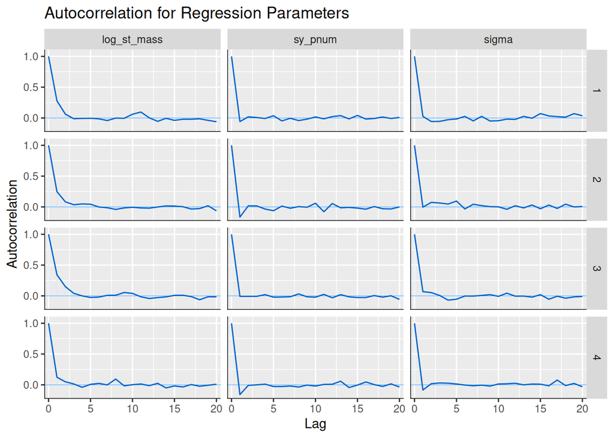

```r
mcmc_acf(posterior_arr, pars = c("log_st_mass", "sy_pnum", "sigma")) +
  ggtitle("Autocorrelation for Regression Parameters")
```

### R-Hat and Effective Sample Size

```r
summary(fit_stanarm)[, c("Rhat", "n_eff")]
```

```
##                    Rhat n_eff
## (Intercept)   1.0004202  2255
## log_st_mass   1.0003518  2313
## st_teff_k     1.0003410  2267
## st_met        0.9996153  3630
## sy_pnum       0.9994302  4841
## sigma         0.9993758  3778
## mean_PPD      0.9999338  3557
## log-posterior 1.0035072  1488
```

## Results and Interpretation

```r
# Summary of coefficients
print(fit_stanarm, digits = 3)
```

```
## stan_glm
##  family:       gaussian [identity]
##  formula:      log_period ~ log_st_mass + st_teff_k + st_met + sy_pnum
##  observations: 3403
##  predictors:   5
## ------
##             Median MAD_SD
## (Intercept)  1.301  0.374
## log_st_mass  0.217  0.161
## st_teff_k    0.137  0.066
## st_met      -0.965  0.141
## sy_pnum      0.108  0.022
##
## Auxiliary parameter(s):
##       Median MAD_SD
## sigma 1.266  0.015
##
## ------
## * For help interpreting the printed output see ?print.stanreg
## * For info on the priors used see ?prior_summary.stanreg
```

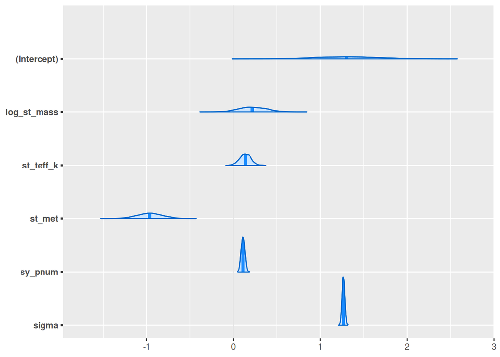

```r
# Visualizing the posterior distributions of coefficients
plot(fit_stanarm, "areas", prob = 0.95, prob_outer = 1)
```

## Predictions

We predict the `log_period` for a hypothetical star with median characteristics but a high number of planets (5 planets).

```r
# Create hypothetical data
new_obs <- data.frame(
  log_st_mass = median(clean_data$log_st_mass),
  st_teff_k = median(clean_data$st_teff_k),
  st_met = median(clean_data$st_met),
  sy_pnum = 5
)

# Generate posterior predictive distribution
post_preds <- posterior_predict(fit_stanarm, newdata = new_obs)

# Summarize prediction
cat("Predicted Log Period (Mean):", mean(post_preds), "\n")
```

```
## Predicted Log Period (Mean): 2.583324
```

```r
cat("95% Prediction Interval:", quantile(post_preds, probs = c(0.025, 0.975)), "\n")
```

```
## 95% Prediction Interval: 0.1553343 5.119856
```

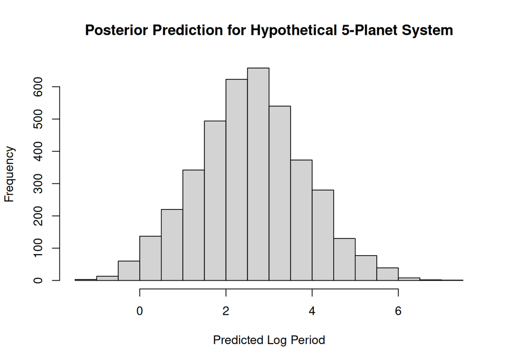

```r
# Histogram of predicted values
hist(post_preds, main = "Posterior Prediction for Hypothetical 5-Planet System", xlab = "Predicted Log Period")
```

## Model Evaluation

We evaluate the model using Posterior Predictive Checks (PPC) and Leave-One-Out Cross-Validation (LOO).

### Posterior Predictive Check

This checks if the data generated by the model looks like the observed data.

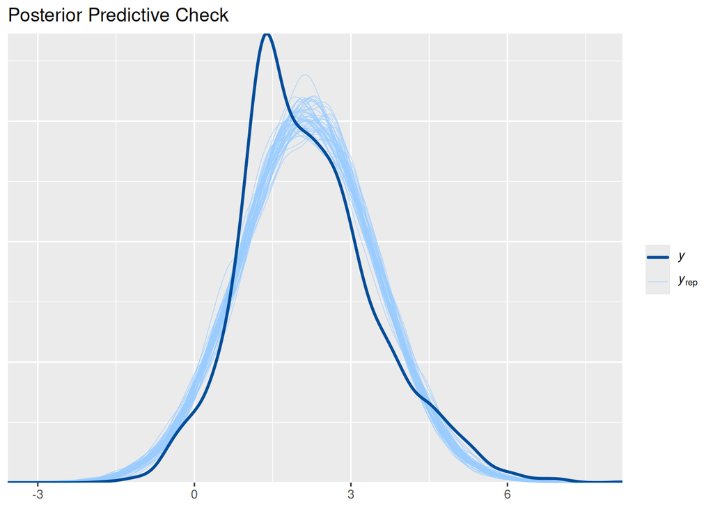

```r
pp_check(fit_stanarm) + ggtitle("Posterior Predictive Check")
```

### Cross Validation (LOO)

We use the PSIS-LOO approximation to estimate the out-of-sample predictive performance.

```r
loo_result <- loo(fit_stanarm)
print(loo_result)
```

```
##
## Computed from 4000 by 3403 log-likelihood matrix.
##
##          Estimate   SE
## elpd_loo  -5635.6 46.1
## p_loo         5.9  0.3
## looic     11271.2 92.2
## ------
## MCSE of elpd_loo is 0.0.
## MCSE and ESS estimates assume independent draws (r_eff=1).
##
## All Pareto k estimates are good (k < 0.7).
## See help('pareto-k-diagnostic') for details.
```